# Meteorite Report

```r
# load in the tidyverse, stringr, assertive, maps and plotting packages.
library(tidyverse)
library(assertthat)
library(assertr)
library(ggplot2)
library(maps)

# load in the cleaning script
source("data_cleaner_script.R")
```

```r
# load in the dirty data
dirty_meteorites <- read_csv("raw_data.csv")

meteorites <- clean_data(dirty_meteorites)
```

```r
dim(meteorites)
```

```
[1] 4823    7
```

The top of the data, showing the column names and some of the data.

```r
head(meteorites)
```

| id | name | mass | fall | year | latitude | longitude |
| --- | --- | --- | --- | --- | --- | --- |
| 5295 | Castrovillari | 15000 | Fell | 1583 | 39.80000 | 16.20000 |
| 16745 | Morito | 10100000 | Found | 1600 | 27.05000 | -105.43333 |
| 12069 | Jalandhar | 1967 | Fell | 1621 | 31.00000 | 75.00000 |
| 23732 | Stretchleigh | 10400 | Fell | 1623 | 50.38333 | -3.95000 |
| 11855 | Hatford | 29000 | Fell | 1628 | 51.65000 | -1.51667 |
| 16692 | Minamino | 1040 | Fell | 1632 | 35.07833 | 136.93333 |

Note, meteorite data only available to 2013.

# MVP Questions

**1** Find the names and years found for the ten largest meteorites

```r
largest_meteorites <- meteorites %>%
  # select only necessary columns
  select(name, mass, year) %>%
  slice_max(mass, n = 10)


largest_meteorites
```

| name | mass | year |
| --- | --- | --- |
| Hoba | 60000000 | 1920 |
| Cape York | 58200000 | 1818 |
| Campo del Cielo | 50000000 | NA |
| Canyon Diablo | 30000000 | 1891 |
| Armanty | 28000000 | 1898 |
| Gibeon | 26000000 | 1836 |
| Chupaderos | 24300000 | 1852 |
| Mundrabilla | 24000000 | 1911 |
| Sikhote-Alin | 23000000 | 1947 |
| Bacubirito | 22000000 | 1863 |

According to the wikipedia entry for Campo del Cielo it was “found” < 1576. This may be why it is recorded as NA in the year table.

**2** Find the average mass of meteorites that were recorded falling, vs. those which were just found.

```r
falling_meteorites <- meteorites %>%
  filter(fall == "Fell")

avg_mass_falling_meteorites <- falling_meteorites %>%
  summarise(avg_mass = mean(mass, na.rm = TRUE)) %>%
  pull()

avg_mass_falling_meteorites
```

```
[1] 69509.95
```

How does this compare with meteorites that were just found?

```r
found_meteorites <- meteorites %>%
  filter(fall == "Found")

avg_mass_found_meteorites <- found_meteorites %>%
  summarise(avg_mass = mean(mass, na.rm = TRUE)) %>%
  pull()

avg_mass_found_meteorites
```

```
[1] 134387.7
```

The average mass of meteorites that are found is around twice that of meteorites observed while falling. This does make sense given the age of the Earth relative to the length of time that humans have existed, and also when not falling from the sky, it’s probably quite difficult to find a small meteorite. A long term study of found meteorites should, therefore, favour larger masses.

**3** Find the number of meteorites in each year, for every year since 2000.

```r
# find only recent meteorites
recent_meteorites <- meteorites %>%
  filter(year >= 2000)

count_meteorites <- recent_meteorites %>%
  add_count(year) %>%
  group_by(year) %>%
  summarise("n_meteorites" = mean(n), .groups = 'drop')

count_meteorites
```

| year | n_meteorites |
| --- | --- |
| 2000 | 234 |
| 2001 | 185 |
| 2002 | 203 |
| 2003 | 208 |
| 2004 | 137 |
| 2005 | 143 |
| 2006 | 166 |
| 2007 | 70 |
| 2008 | 95 |
| 2009 | 103 |

[output cut: 4 more lines]

# Extension

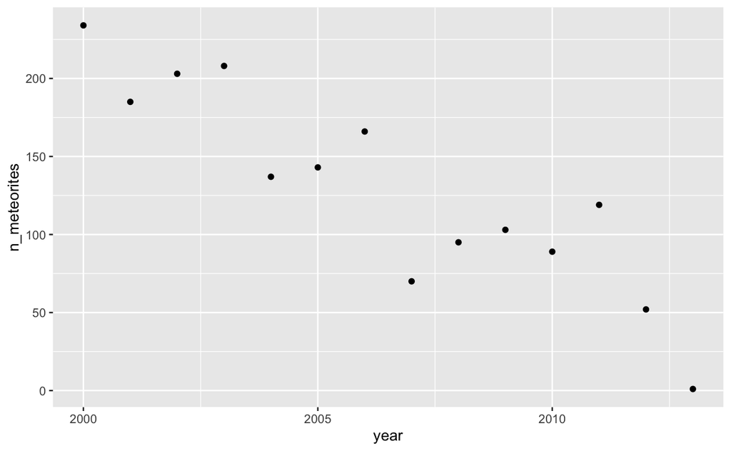

```r
ggplot() +
  geom_point(data = count_meteorites, aes(x = year, y = n_meteorites))
```

The trend is that over time, less meteorites are recorded per year.

What is trend in meteorites observed to have fallen in the same period?

```r
count_fell_meteorites <- recent_meteorites %>%
  filter(fall == "Fell") %>%
  add_count(year) %>%
  group_by(year) %>%
  summarise("n_fell_meteorites" = mean(n), .groups = 'drop')
```

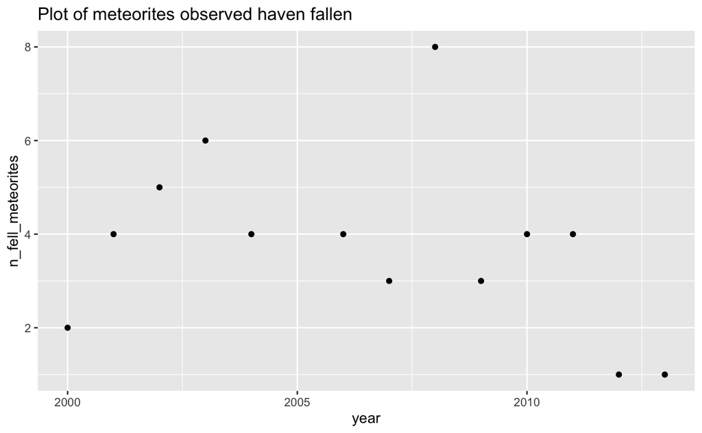

```r
ggplot() +
  geom_point(data = count_fell_meteorites,
             aes(x = year, y = n_fell_meteorites)) +
  labs(title = "Plot of meteorites observed haven fallen")
```

While the number of meteorites per year has decreased over time, the number of meteorites observed falling has not, but has remained consistently low. The implication then is that we are finding old meteorites faster than new ones are falling.

The data includes lat/long co-ordinates. Plot every meteorite on a map of the world, placed where it was found.

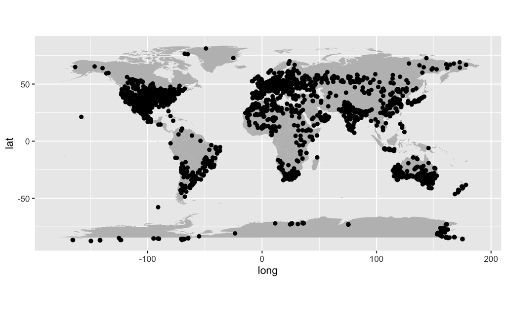

```r
# load in world map
earth_map <- map_data("world")

meteorites <- meteorites %>%
  filter(latitude!=0 & longitude !=0)

ggplot() +
  # continental grey background
  geom_polygon(data = earth_map, aes(x = long, y = lat, group = group),
               fill = "grey", alpha = 1.5) +
  # plot lat/longs on top
  geom_point(data=meteorites, aes(x=longitude, y=latitude)) +
  coord_fixed()
```

Plot only the largest (greatest mass) meteorites on the world map.

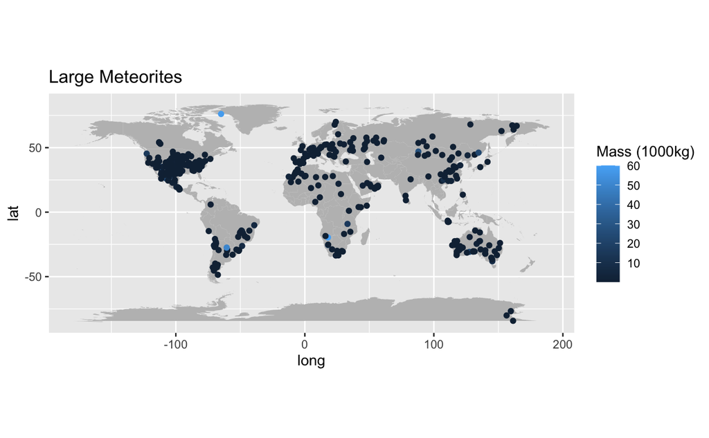

```r
large_meteorites <- meteorites %>%
  # the selection of large meteorites will be those greater than the avg mass
  filter(mass > avg_mass_falling_meteorites) %>%
  # change the units of mass from grams to something more sensible for the plot
  mutate(mass = mass/1000/1000)


ggplot() +
  # plot map
  geom_polygon(data = earth_map, aes(x = long, y = lat, group = group),
               fill = "grey", alpha = 1.5) +
  # plot data
  geom_point(data = large_meteorites,
             aes(x = longitude, y=latitude, color = mass)) +
  coord_fixed() +
  labs(color = "Mass (1000kg)", title = "Large Meteorites")
```

From the plot very few meteorites exist in the largest mass category. Most are < 10*1000kg. It may be that a few very very large meteorites drag the mean average up. How does the median average of falling meteorites compare.

```r
median_avg_mass <- falling_meteorites %>%
  summarise(avg_mass = median(mass, na.rm = TRUE)) %>%
  pull()

median_avg_mass
```

```
[1] 6000
```

It is less than 1/10th of what the mean is. The implication then is that the majority of meteorites are considerably less than the mean average mass.

Plot the meteorites found falling in the last 100 years.

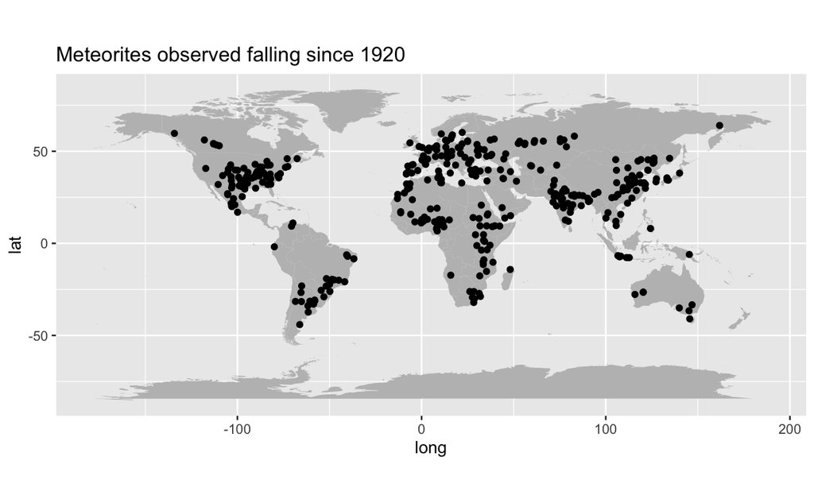

```r
meteorites_last_100_years <- falling_meteorites %>%
  filter(year > 1920) %>%
  filter(latitude != 0 & longitude != 0)

ggplot() +
  geom_polygon(data = earth_map, aes(x = long, y = lat, group = group),
               fill = "grey", alpha = 1.5) +
  geom_point(data = meteorites_last_100_years,
             aes(x = longitude, y = latitude)) +
  coord_fixed() +
  labs(title = "Meteorites observed falling since 1920")
```

Plot the meteorites observed falling in the past 40 years. Distinguish decade by colour.

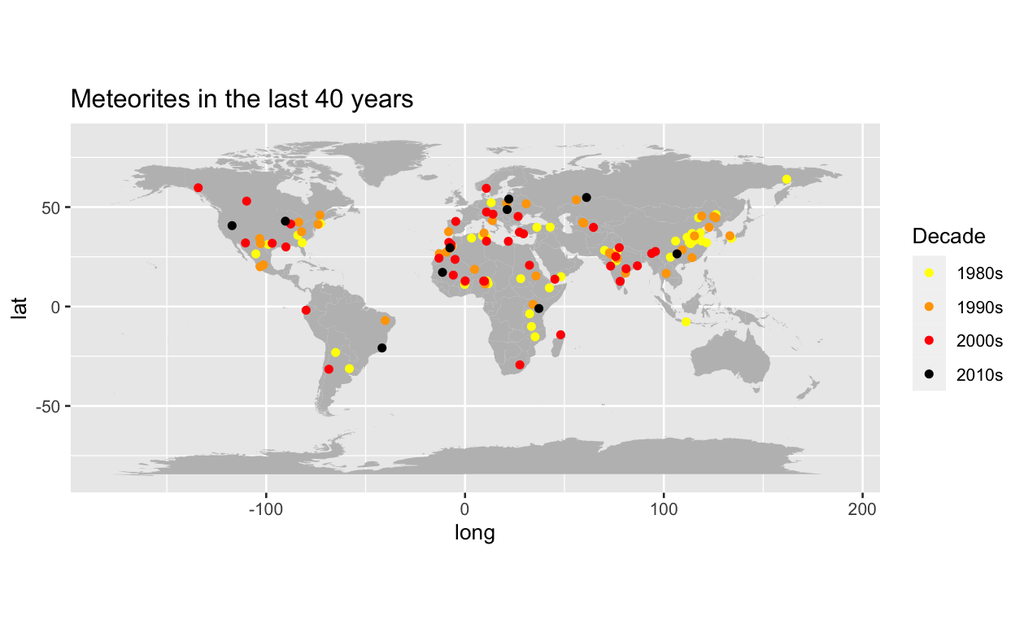

```r
recent_meteorites <- meteorites_last_100_years %>%
  filter(year >= 1980) %>%
  mutate(decade = case_when(
    year >= 1980 & year < 1990 ~ "1980s",
    year >= 1990 & year < 2000 ~ "1990s",
    year >= 2000 & year < 2010 ~ "2000s",
    year >= 2010 & year < 2020 ~ "2010s"
  )) %>%
  group_by(decade)

ggplot() +
  geom_polygon(data = earth_map, aes(x = long, y = lat, group = group),
               fill = "grey", alpha = 1.5) +
  geom_point(data = recent_meteorites,
             aes(x = longitude, y = latitude, colour = decade)) +
  scale_color_manual(values = c("1980s" = "yellow",
                                "1990s" = "orange",
                                "2000s" = "red",
                                "2010s" = "black")) +
  coord_fixed() +
  labs(color = "Decade", title = "Meteorites in the last 40 years")
```

Note, meteorite data only available to 2013.